# Risk Factor Analysis

## Outcome Variable

**Outcome Variable:** haz

## Predictor Variables

**Intervention Variable:** hhwealth_quart

**Adjustment Set:**

- arm
- sex
- W_mage
- meducyrs
- feducyrs
- W_gagebrth
- W_birthwt
- W_birthlen
- W_nchldlt5
- W_parity
- delta_W_mage
- delta_meducyrs
- delta_feducyrs
- delta_W_gagebrth
- delta_W_birthwt
- delta_W_birthlen
- delta_W_nchldlt5
- delta_W_parity

## Stratifying Variables

The analysis was stratified on these variable(s):

- agecat
- studyid
- country

## Data Summary

| agecat | studyid | country | hhwealth_quart | n_cell | n |
| --- | --- | --- | --- | --- | --- |
| Birth | ki0047075b-MAL-ED | BANGLADESH | Wealth Q4 | 21 | 82 |
| Birth | ki0047075b-MAL-ED | BANGLADESH | Wealth Q1 | 21 | 82 |
| Birth | ki0047075b-MAL-ED | BANGLADESH | Wealth Q2 | 20 | 82 |
| Birth | ki0047075b-MAL-ED | BANGLADESH | Wealth Q3 | 20 | 82 |
| Birth | ki0047075b-MAL-ED | INDIA | Wealth Q4 | 12 | 55 |
| Birth | ki0047075b-MAL-ED | INDIA | Wealth Q1 | 17 | 55 |
| Birth | ki0047075b-MAL-ED | INDIA | Wealth Q2 | 15 | 55 |
| Birth | ki0047075b-MAL-ED | INDIA | Wealth Q3 | 11 | 55 |
| Birth | ki0047075b-MAL-ED | NEPAL | Wealth Q4 | 9 | 31 |
| Birth | ki0047075b-MAL-ED | NEPAL | Wealth Q1 | 8 | 31 |
| Birth | ki0047075b-MAL-ED | NEPAL | Wealth Q2 | 7 | 31 |
| Birth | ki0047075b-MAL-ED | NEPAL | Wealth Q3 | 7 | 31 |
| Birth | ki0047075b-MAL-ED | PERU | Wealth Q4 | 10 | 36 |
| Birth | ki0047075b-MAL-ED | PERU | Wealth Q1 | 9 | 36 |
| Birth | ki0047075b-MAL-ED | PERU | Wealth Q2 | 9 | 36 |
| Birth | ki0047075b-MAL-ED | PERU | Wealth Q3 | 8 | 36 |
| Birth | ki0047075b-MAL-ED | SOUTH AFRICA | Wealth Q4 | 15 | 61 |
| Birth | ki0047075b-MAL-ED | SOUTH AFRICA | Wealth Q1 | 16 | 61 |
| Birth | ki0047075b-MAL-ED | SOUTH AFRICA | Wealth Q2 | 14 | 61 |
| Birth | ki0047075b-MAL-ED | SOUTH AFRICA | Wealth Q3 | 16 | 61 |
| Birth | ki0047075b-MAL-ED | TANZANIA, UNITED REPUBLIC OF | Wealth Q4 | 5 | 23 |
| Birth | ki0047075b-MAL-ED | TANZANIA, UNITED REPUBLIC OF | Wealth Q1 | 6 | 23 |
| Birth | ki0047075b-MAL-ED | TANZANIA, UNITED REPUBLIC OF | Wealth Q2 | 7 | 23 |
| Birth | ki0047075b-MAL-ED | TANZANIA, UNITED REPUBLIC OF | Wealth Q3 | 5 | 23 |
| Birth | ki1000108-CMC-V-BCS-2002 | INDIA | Wealth Q4 | 31 | 90 |
| Birth | ki1000108-CMC-V-BCS-2002 | INDIA | Wealth Q1 | 14 | 90 |
| Birth | ki1000108-CMC-V-BCS-2002 | INDIA | Wealth Q2 | 20 | 90 |
| Birth | ki1000108-CMC-V-BCS-2002 | INDIA | Wealth Q3 | 25 | 90 |
| Birth | ki1000108-IRC | INDIA | Wealth Q4 | 91 | 388 |
| Birth | ki1000108-IRC | INDIA | Wealth Q1 | 98 | 388 |

[output cut: 158 more lines]

The following strata were considered:

- agecat: 24 months, studyid: ki0047075b-MAL-ED, country: BANGLADESH
- agecat: 24 months, studyid: ki0047075b-MAL-ED, country: INDIA
- agecat: 24 months, studyid: ki0047075b-MAL-ED, country: NEPAL
- agecat: 24 months, studyid: ki0047075b-MAL-ED, country: PERU
- agecat: 24 months, studyid: ki0047075b-MAL-ED, country: SOUTH AFRICA
- agecat: 24 months, studyid: ki0047075b-MAL-ED, country: TANZANIA, UNITED REPUBLIC OF
- agecat: 24 months, studyid: ki1000108-CMC-V-BCS-2002, country: INDIA
- agecat: 24 months, studyid: ki1000108-IRC, country: INDIA
- agecat: 24 months, studyid: ki1017093b-PROVIDE, country: BANGLADESH
- agecat: 24 months, studyid: ki1066203-TanzaniaChild2, country: TANZANIA, UNITED REPUBLIC OF
- agecat: 24 months, studyid: ki1113344-GMS-Nepal, country: NEPAL
- agecat: 24 months, studyid: ki1114097-CONTENT, country: PERU
- agecat: 24 months, studyid: ki1135781-COHORTS, country: GUATEMALA
- agecat: 24 months, studyid: ki1135781-COHORTS, country: PHILIPPINES
- agecat: 24 months, studyid: ki1148112-LCNI-5, country: MALAWI
- agecat: 24 months, studyid: kiGH5241-JiVitA-3, country: BANGLADESH
- agecat: 24 months, studyid: kiGH5241-JiVitA-4, country: BANGLADESH
- agecat: 6 months, studyid: ki0047075b-MAL-ED, country: BANGLADESH
- agecat: 6 months, studyid: ki0047075b-MAL-ED, country: INDIA
- agecat: 6 months, studyid: ki0047075b-MAL-ED, country: NEPAL
- agecat: 6 months, studyid: ki0047075b-MAL-ED, country: PERU
- agecat: 6 months, studyid: ki0047075b-MAL-ED, country: SOUTH AFRICA
- agecat: 6 months, studyid: ki0047075b-MAL-ED, country: TANZANIA, UNITED REPUBLIC OF
- agecat: 6 months, studyid: ki1000108-CMC-V-BCS-2002, country: INDIA
- agecat: 6 months, studyid: ki1000108-IRC, country: INDIA
- agecat: 6 months, studyid: ki1017093b-PROVIDE, country: BANGLADESH
- agecat: 6 months, studyid: ki1066203-TanzaniaChild2, country: TANZANIA, UNITED REPUBLIC OF
- agecat: 6 months, studyid: ki1113344-GMS-Nepal, country: NEPAL
- agecat: 6 months, studyid: ki1114097-CONTENT, country: PERU
- agecat: 6 months, studyid: ki1135781-COHORTS, country: GUATEMALA
- agecat: 6 months, studyid: ki1135781-COHORTS, country: PHILIPPINES
- agecat: 6 months, studyid: ki1148112-LCNI-5, country: MALAWI
- agecat: 6 months, studyid: kiGH5241-JiVitA-3, country: BANGLADESH
- agecat: 6 months, studyid: kiGH5241-JiVitA-4, country: BANGLADESH
- agecat: Birth, studyid: ki0047075b-MAL-ED, country: BANGLADESH
- agecat: Birth, studyid: ki0047075b-MAL-ED, country: INDIA
- agecat: Birth, studyid: ki0047075b-MAL-ED, country: NEPAL
- agecat: Birth, studyid: ki0047075b-MAL-ED, country: PERU
- agecat: Birth, studyid: ki0047075b-MAL-ED, country: SOUTH AFRICA
- agecat: Birth, studyid: ki0047075b-MAL-ED, country: TANZANIA, UNITED REPUBLIC OF
- agecat: Birth, studyid: ki1000108-CMC-V-BCS-2002, country: INDIA
- agecat: Birth, studyid: ki1000108-IRC, country: INDIA
- agecat: Birth, studyid: ki1114097-CONTENT, country: PERU
- agecat: Birth, studyid: ki1135781-COHORTS, country: GUATEMALA
- agecat: Birth, studyid: ki1135781-COHORTS, country: PHILIPPINES
- agecat: Birth, studyid: kiGH5241-JiVitA-3, country: BANGLADESH
- agecat: Birth, studyid: kiGH5241-JiVitA-4, country: BANGLADESH

### Dropped Strata

Some strata were dropped due to rare outcomes:

- agecat: Birth, studyid: ki1114097-CONTENT, country: PERU
- agecat: 24 months, studyid: ki1066203-TanzaniaChild2, country: TANZANIA, UNITED REPUBLIC OF

## Methods Detail

We’re interested in the causal parameters $E[Y_a]$ for all values of $a \in \mathcal{A}$. These parameters represent the mean outcome if, possibly contrary to fact, we intervened to set all units to have $A=a$. Under the randomization and positivity assumptions, these are identified by the statistical parameters $\psi_a=E_W[E_{Y|A,W}(Y|A=a,W)]$. In addition, we’re interested in the mean of $Y$, $E[Y]$ under no intervention (the observed mean). We will estimate these parameters by using SuperLearner to fit the relevant likelihood factors – $E_{Y|A,W}(Y|A=a,W)$ and $p(A=a|W)$, and then updating our likelihood fit using a joint TMLE.

For unadjusted analyses ($W=\{\}$), initial likelihoods were estimated using Lrnr_glm to estimate the simple $E(Y|A)$ and Lrnr_mean to estimate $p(A)$. For adjusted analyses, a small library containing Lrnr_glmnet, Lrnr_xgboost, and Lrnr_mean was used.

Having estimated these parameters, we will then use the delta method to estimate relative risks and attributable risks relative to a prespecified baseline level of $A$.

# Results Detail

## Results Plots

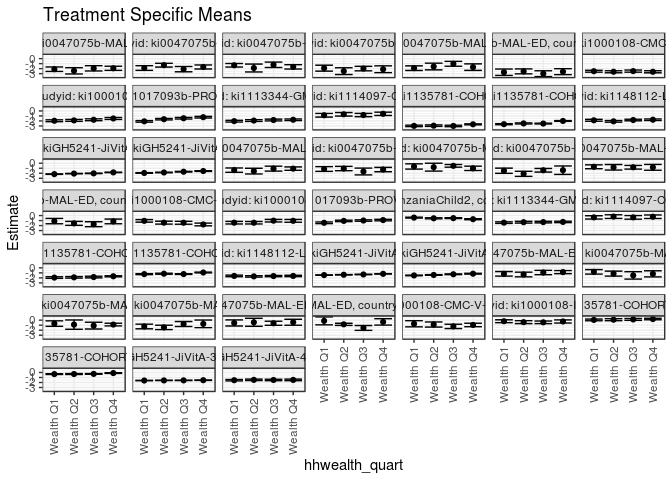

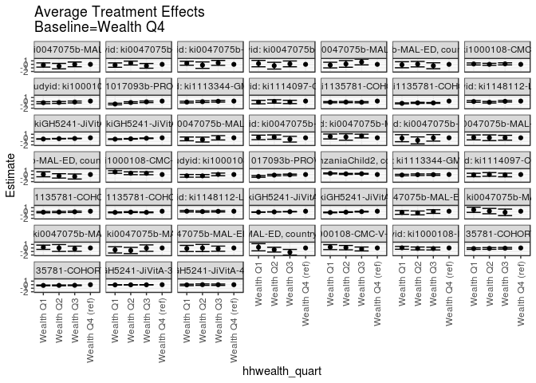

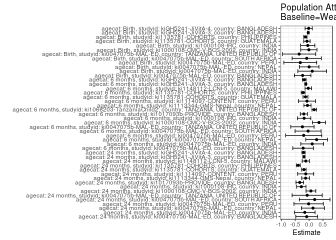

## Results Table

### Parameter: TSM

| agecat | studyid | country | intervention_level | baseline_level | estimate | ci_lower | ci_upper |
| --- | --- | --- | --- | --- | --- | --- | --- |
| Birth | ki0047075b-MAL-ED | BANGLADESH | Wealth Q4 | NA | -0.8490478 | -1.1576195 | -0.5404761 |
| Birth | ki0047075b-MAL-ED | BANGLADESH | Wealth Q1 | NA | -1.1904762 | -1.6458675 | -0.7350848 |
| Birth | ki0047075b-MAL-ED | BANGLADESH | Wealth Q2 | NA | -1.3255748 | -1.7912866 | -0.8598629 |
| Birth | ki0047075b-MAL-ED | BANGLADESH | Wealth Q3 | NA | -0.9326454 | -1.3620707 | -0.5032201 |
| Birth | ki0047075b-MAL-ED | INDIA | Wealth Q4 | NA | -1.1972317 | -1.8092770 | -0.5851864 |
| Birth | ki0047075b-MAL-ED | INDIA | Wealth Q1 | NA | -0.7953942 | -1.2437001 | -0.3470884 |
| Birth | ki0047075b-MAL-ED | INDIA | Wealth Q2 | NA | -1.1506966 | -1.6487447 | -0.6526486 |
| Birth | ki0047075b-MAL-ED | INDIA | Wealth Q3 | NA | -1.5069937 | -2.2446314 | -0.7693560 |
| Birth | ki0047075b-MAL-ED | NEPAL | Wealth Q4 | NA | -0.8788889 | -1.1434362 | -0.6143415 |
| Birth | ki0047075b-MAL-ED | NEPAL | Wealth Q1 | NA | -0.6800000 | -1.2219811 | -0.1380189 |
| Birth | ki0047075b-MAL-ED | NEPAL | Wealth Q2 | NA | -0.8871429 | -1.8180540 | 0.0437683 |
| Birth | ki0047075b-MAL-ED | NEPAL | Wealth Q3 | NA | -1.0900000 | -1.7651391 | -0.4148609 |
| Birth | ki0047075b-MAL-ED | PERU | Wealth Q4 | NA | -0.7340000 | -1.4942378 | 0.0262378 |
| Birth | ki0047075b-MAL-ED | PERU | Wealth Q1 | NA | -1.2622222 | -1.7251583 | -0.7992862 |
| Birth | ki0047075b-MAL-ED | PERU | Wealth Q2 | NA | -1.4455556 | -1.8778392 | -1.0132719 |
| Birth | ki0047075b-MAL-ED | PERU | Wealth Q3 | NA | -0.7675000 | -1.2626961 | -0.2723039 |
| Birth | ki0047075b-MAL-ED | SOUTH AFRICA | Wealth Q4 | NA | -0.4155938 | -1.0099977 | 0.1788101 |
| Birth | ki0047075b-MAL-ED | SOUTH AFRICA | Wealth Q1 | NA | -0.5551930 | -1.1650100 | 0.0546241 |
| Birth | ki0047075b-MAL-ED | SOUTH AFRICA | Wealth Q2 | NA | -0.4239166 | -1.2196165 | 0.3717833 |
| Birth | ki0047075b-MAL-ED | SOUTH AFRICA | Wealth Q3 | NA | -0.6213178 | -1.0257950 | -0.2168407 |
| Birth | ki0047075b-MAL-ED | TANZANIA, UNITED REPUBLIC OF | Wealth Q4 | NA | -0.3460000 | -0.9837324 | 0.2917324 |
| Birth | ki0047075b-MAL-ED | TANZANIA, UNITED REPUBLIC OF | Wealth Q1 | NA | -0.1416667 | -0.9344057 | 0.6510723 |
| Birth | ki0047075b-MAL-ED | TANZANIA, UNITED REPUBLIC OF | Wealth Q2 | NA | -0.8314286 | -1.0437617 | -0.6190954 |
| Birth | ki0047075b-MAL-ED | TANZANIA, UNITED REPUBLIC OF | Wealth Q3 | NA | -1.5520000 | -2.0330768 | -1.0709232 |
| Birth | ki1000108-CMC-V-BCS-2002 | INDIA | Wealth Q4 | NA | -0.9572614 | -1.2998237 | -0.6146991 |
| Birth | ki1000108-CMC-V-BCS-2002 | INDIA | Wealth Q1 | NA | -0.7202534 | -1.3302475 | -0.1102594 |
| Birth | ki1000108-CMC-V-BCS-2002 | INDIA | Wealth Q2 | NA | -0.8687263 | -1.3790463 | -0.3584063 |
| Birth | ki1000108-CMC-V-BCS-2002 | INDIA | Wealth Q3 | NA | -1.2399081 | -1.6680578 | -0.8117585 |
| Birth | ki1000108-IRC | INDIA | Wealth Q4 | NA | -0.2598505 | -0.5747638 | 0.0550627 |
| Birth | ki1000108-IRC | INDIA | Wealth Q1 | NA | -0.2127573 | -0.4971361 | 0.0716215 |

[output cut: 150 more lines]

### Parameter: E(Y)

| agecat | studyid | country | intervention_level | baseline_level | estimate | ci_lower | ci_upper |
| --- | --- | --- | --- | --- | --- | --- | --- |
| Birth | ki0047075b-MAL-ED | BANGLADESH | NA | NA | -1.0813415 | -1.3098662 | -0.8528167 |
| Birth | ki0047075b-MAL-ED | INDIA | NA | NA | -1.0841818 | -1.3853089 | -0.7830548 |
| Birth | ki0047075b-MAL-ED | NEPAL | NA | NA | -0.8770968 | -1.1861056 | -0.5680880 |
| Birth | ki0047075b-MAL-ED | PERU | NA | NA | -1.0513889 | -1.3551960 | -0.7475818 |
| Birth | ki0047075b-MAL-ED | SOUTH AFRICA | NA | NA | -0.5011475 | -0.7582104 | -0.2440847 |
| Birth | ki0047075b-MAL-ED | TANZANIA, UNITED REPUBLIC OF | NA | NA | -0.7026087 | -1.0554952 | -0.3497222 |
| Birth | ki1000108-CMC-V-BCS-2002 | INDIA | NA | NA | -0.9654444 | -1.1742112 | -0.7566777 |
| Birth | ki1000108-IRC | INDIA | NA | NA | -0.3080412 | -0.4687931 | -0.1472894 |
| Birth | ki1135781-COHORTS | GUATEMALA | NA | NA | 0.1452941 | 0.0610109 | 0.2295774 |
| Birth | ki1135781-COHORTS | PHILIPPINES | NA | NA | -0.2491505 | -0.2881717 | -0.2101294 |
| Birth | kiGH5241-JiVitA-3 | BANGLADESH | NA | NA | -1.5750490 | -1.5948262 | -1.5552718 |
| Birth | kiGH5241-JiVitA-4 | BANGLADESH | NA | NA | -1.4976642 | -1.5817349 | -1.4135935 |
| 6 months | ki0047075b-MAL-ED | BANGLADESH | NA | NA | -1.2886008 | -1.5330953 | -1.0441063 |
| 6 months | ki0047075b-MAL-ED | INDIA | NA | NA | -1.1499296 | -1.3858882 | -0.9139710 |
| 6 months | ki0047075b-MAL-ED | NEPAL | NA | NA | -0.7429762 | -0.9817457 | -0.5042067 |
| 6 months | ki0047075b-MAL-ED | PERU | NA | NA | -1.5801389 | -1.8994566 | -1.2608211 |
| 6 months | ki0047075b-MAL-ED | SOUTH AFRICA | NA | NA | -0.8550000 | -1.0838479 | -0.6261521 |
| 6 months | ki0047075b-MAL-ED | TANZANIA, UNITED REPUBLIC OF | NA | NA | -1.4104598 | -1.6281211 | -1.1927984 |
| 6 months | ki1000108-CMC-V-BCS-2002 | INDIA | NA | NA | -1.4234508 | -1.5645974 | -1.2823042 |
| 6 months | ki1000108-IRC | INDIA | NA | NA | -1.2344062 | -1.3658524 | -1.1029600 |
| 6 months | ki1017093b-PROVIDE | BANGLADESH | NA | NA | -1.0925674 | -1.1686395 | -1.0164954 |
| 6 months | ki1066203-TanzaniaChild2 | TANZANIA, UNITED REPUBLIC OF | NA | NA | -0.5442232 | -0.5932373 | -0.4952090 |
| 6 months | ki1113344-GMS-Nepal | NEPAL | NA | NA | -1.3321522 | -1.4103691 | -1.2539352 |
| 6 months | ki1114097-CONTENT | PERU | NA | NA | -0.3139217 | -0.4868486 | -0.1409948 |
| 6 months | ki1135781-COHORTS | GUATEMALA | NA | NA | -1.8112324 | -1.8807284 | -1.7417365 |
| 6 months | ki1135781-COHORTS | PHILIPPINES | NA | NA | -1.1405724 | -1.1824954 | -1.0986493 |
| 6 months | ki1148112-LCNI-5 | MALAWI | NA | NA | -1.6426961 | -1.7120603 | -1.5733318 |
| 6 months | kiGH5241-JiVitA-3 | BANGLADESH | NA | NA | -1.3132090 | -1.3363486 | -1.2900693 |
| 6 months | kiGH5241-JiVitA-4 | BANGLADESH | NA | NA | -1.3440477 | -1.3813060 | -1.3067894 |
| 24 months | ki0047075b-MAL-ED | BANGLADESH | NA | NA | -2.0155844 | -2.2679754 | -1.7631934 |
| 24 months | ki0047075b-MAL-ED | INDIA | NA | NA | -1.8247183 | -2.0459767 | -1.6034599 |
| 24 months | ki0047075b-MAL-ED | NEPAL | NA | NA | -1.5063095 | -1.7704452 | -1.2421738 |
| 24 months | ki0047075b-MAL-ED | PERU | NA | NA | -2.1384375 | -2.4638687 | -1.8130063 |
| 24 months | ki0047075b-MAL-ED | SOUTH AFRICA | NA | NA | -1.4993939 | -1.7838130 | -1.2149749 |
| 24 months | ki0047075b-MAL-ED | TANZANIA, UNITED REPUBLIC OF | NA | NA | -2.6744068 | -2.9325198 | -2.4162938 |
| 24 months | ki1000108-CMC-V-BCS-2002 | INDIA | NA | NA | -2.5593683 | -2.6601027 | -2.4586339 |
| 24 months | ki1000108-IRC | INDIA | NA | NA | -1.7824776 | -1.8765600 | -1.6883952 |
| 24 months | ki1017093b-PROVIDE | BANGLADESH | NA | NA | -1.5853993 | -1.6687810 | -1.5020176 |
| 24 months | ki1113344-GMS-Nepal | NEPAL | NA | NA | -1.8835905 | -1.9681499 | -1.7990312 |
| 24 months | ki1114097-CONTENT | PERU | NA | NA | -0.6962195 | -0.8674103 | -0.5250287 |
| 24 months | ki1135781-COHORTS | GUATEMALA | NA | NA | -2.8581407 | -2.9236747 | -2.7926066 |
| 24 months | ki1135781-COHORTS | PHILIPPINES | NA | NA | -2.3898650 | -2.4346888 | -2.3450412 |
| 24 months | ki1148112-LCNI-5 | MALAWI | NA | NA | -1.8714634 | -1.9528558 | -1.7900711 |
| 24 months | kiGH5241-JiVitA-3 | BANGLADESH | NA | NA | -2.0125560 | -2.0402683 | -1.9848436 |
| 24 months | kiGH5241-JiVitA-4 | BANGLADESH | NA | NA | -1.7578934 | -1.7933205 | -1.7224663 |

### Parameter: ATE

| agecat | studyid | country | intervention_level | baseline_level | estimate | ci_lower | ci_upper |
| --- | --- | --- | --- | --- | --- | --- | --- |
| Birth | ki0047075b-MAL-ED | BANGLADESH | Wealth Q4 | Wealth Q4 | 0.0000000 | 0.0000000 | 0.0000000 |
| Birth | ki0047075b-MAL-ED | BANGLADESH | Wealth Q1 | Wealth Q4 | -0.3414283 | -0.8756311 | 0.1927745 |
| Birth | ki0047075b-MAL-ED | BANGLADESH | Wealth Q2 | Wealth Q4 | -0.4765269 | -1.0220896 | 0.0690357 |
| Birth | ki0047075b-MAL-ED | BANGLADESH | Wealth Q3 | Wealth Q4 | -0.0835976 | -0.6016183 | 0.4344232 |
| Birth | ki0047075b-MAL-ED | INDIA | Wealth Q4 | Wealth Q4 | 0.0000000 | 0.0000000 | 0.0000000 |
| Birth | ki0047075b-MAL-ED | INDIA | Wealth Q1 | Wealth Q4 | 0.4018375 | -0.3267737 | 1.1304487 |
| Birth | ki0047075b-MAL-ED | INDIA | Wealth Q2 | Wealth Q4 | 0.0465351 | -0.7069377 | 0.8000078 |
| Birth | ki0047075b-MAL-ED | INDIA | Wealth Q3 | Wealth Q4 | -0.3097620 | -1.2300442 | 0.6105202 |
| Birth | ki0047075b-MAL-ED | NEPAL | Wealth Q4 | Wealth Q4 | 0.0000000 | 0.0000000 | 0.0000000 |
| Birth | ki0047075b-MAL-ED | NEPAL | Wealth Q1 | Wealth Q4 | 0.1988889 | -0.4042105 | 0.8019883 |
| Birth | ki0047075b-MAL-ED | NEPAL | Wealth Q2 | Wealth Q4 | -0.0082540 | -0.9760250 | 0.9595171 |
| Birth | ki0047075b-MAL-ED | NEPAL | Wealth Q3 | Wealth Q4 | -0.2111111 | -0.9362305 | 0.5140083 |
| Birth | ki0047075b-MAL-ED | PERU | Wealth Q4 | Wealth Q4 | 0.0000000 | 0.0000000 | 0.0000000 |
| Birth | ki0047075b-MAL-ED | PERU | Wealth Q1 | Wealth Q4 | -0.5282222 | -1.4183185 | 0.3618740 |
| Birth | ki0047075b-MAL-ED | PERU | Wealth Q2 | Wealth Q4 | -0.7115556 | -1.5861016 | 0.1629905 |
| Birth | ki0047075b-MAL-ED | PERU | Wealth Q3 | Wealth Q4 | -0.0335000 | -0.9407931 | 0.8737931 |
| Birth | ki0047075b-MAL-ED | SOUTH AFRICA | Wealth Q4 | Wealth Q4 | 0.0000000 | 0.0000000 | 0.0000000 |
| Birth | ki0047075b-MAL-ED | SOUTH AFRICA | Wealth Q1 | Wealth Q4 | -0.1395992 | -1.0090787 | 0.7298804 |
| Birth | ki0047075b-MAL-ED | SOUTH AFRICA | Wealth Q2 | Wealth Q4 | -0.0083228 | -1.0138512 | 0.9972056 |
| Birth | ki0047075b-MAL-ED | SOUTH AFRICA | Wealth Q3 | Wealth Q4 | -0.2057240 | -0.9346004 | 0.5231524 |
| Birth | ki0047075b-MAL-ED | TANZANIA, UNITED REPUBLIC OF | Wealth Q4 | Wealth Q4 | 0.0000000 | 0.0000000 | 0.0000000 |
| Birth | ki0047075b-MAL-ED | TANZANIA, UNITED REPUBLIC OF | Wealth Q1 | Wealth Q4 | 0.2043333 | -0.8130839 | 1.2217505 |
| Birth | ki0047075b-MAL-ED | TANZANIA, UNITED REPUBLIC OF | Wealth Q2 | Wealth Q4 | -0.4854286 | -1.1575804 | 0.1867232 |
| Birth | ki0047075b-MAL-ED | TANZANIA, UNITED REPUBLIC OF | Wealth Q3 | Wealth Q4 | -1.2060000 | -2.0048351 | -0.4071649 |
| Birth | ki1000108-CMC-V-BCS-2002 | INDIA | Wealth Q4 | Wealth Q4 | 0.0000000 | 0.0000000 | 0.0000000 |
| Birth | ki1000108-CMC-V-BCS-2002 | INDIA | Wealth Q1 | Wealth Q4 | 0.2370080 | -0.4649186 | 0.9389345 |
| Birth | ki1000108-CMC-V-BCS-2002 | INDIA | Wealth Q2 | Wealth Q4 | 0.0885351 | -0.5269574 | 0.7040276 |
| Birth | ki1000108-CMC-V-BCS-2002 | INDIA | Wealth Q3 | Wealth Q4 | -0.2826467 | -0.8355798 | 0.2702864 |
| Birth | ki1000108-IRC | INDIA | Wealth Q4 | Wealth Q4 | 0.0000000 | 0.0000000 | 0.0000000 |
| Birth | ki1000108-IRC | INDIA | Wealth Q1 | Wealth Q4 | 0.0470933 | -0.3570984 | 0.4512850 |

[output cut: 150 more lines]

### Parameter: PAR

| agecat | studyid | country | intervention_level | baseline_level | estimate | ci_lower | ci_upper |
| --- | --- | --- | --- | --- | --- | --- | --- |
| Birth | ki0047075b-MAL-ED | BANGLADESH | Wealth Q4 | NA | -0.2322936 | -0.5303639 | 0.0657767 |
| Birth | ki0047075b-MAL-ED | INDIA | Wealth Q4 | NA | 0.1130499 | -0.4047797 | 0.6308795 |
| Birth | ki0047075b-MAL-ED | NEPAL | Wealth Q4 | NA | 0.0017921 | -0.3515280 | 0.3551122 |
| Birth | ki0047075b-MAL-ED | PERU | Wealth Q4 | NA | -0.3173889 | -0.9082955 | 0.2735177 |
| Birth | ki0047075b-MAL-ED | SOUTH AFRICA | Wealth Q4 | NA | -0.0855537 | -0.6104616 | 0.4393541 |
| Birth | ki0047075b-MAL-ED | TANZANIA, UNITED REPUBLIC OF | Wealth Q4 | NA | -0.3566087 | -0.9519273 | 0.2387100 |
| Birth | ki1000108-CMC-V-BCS-2002 | INDIA | Wealth Q4 | NA | -0.0081830 | -0.3007580 | 0.2843919 |
| Birth | ki1000108-IRC | INDIA | Wealth Q4 | NA | -0.0481907 | -0.3034380 | 0.2070566 |
| Birth | ki1135781-COHORTS | GUATEMALA | Wealth Q4 | NA | -0.0769527 | -0.1910597 | 0.0371542 |
| Birth | ki1135781-COHORTS | PHILIPPINES | Wealth Q4 | NA | -0.1330913 | -0.1907943 | -0.0753882 |
| Birth | kiGH5241-JiVitA-3 | BANGLADESH | Wealth Q4 | NA | -0.0300669 | -0.0596631 | -0.0004706 |
| Birth | kiGH5241-JiVitA-4 | BANGLADESH | Wealth Q4 | NA | -0.0156882 | -0.1447145 | 0.1133382 |
| 6 months | ki0047075b-MAL-ED | BANGLADESH | Wealth Q4 | NA | -0.2130910 | -0.5848836 | 0.1587016 |
| 6 months | ki0047075b-MAL-ED | INDIA | Wealth Q4 | NA | 0.1127421 | -0.2972855 | 0.5227697 |
| 6 months | ki0047075b-MAL-ED | NEPAL | Wealth Q4 | NA | 0.2718848 | -0.1190699 | 0.6628396 |
| 6 months | ki0047075b-MAL-ED | PERU | Wealth Q4 | NA | -0.1941389 | -0.8422573 | 0.4539796 |
| 6 months | ki0047075b-MAL-ED | SOUTH AFRICA | Wealth Q4 | NA | -0.0366248 | -0.5048605 | 0.4316109 |
| 6 months | ki0047075b-MAL-ED | TANZANIA, UNITED REPUBLIC OF | Wealth Q4 | NA | -0.2396884 | -0.6587881 | 0.1794113 |
| 6 months | ki1000108-CMC-V-BCS-2002 | INDIA | Wealth Q4 | NA | 0.3566336 | 0.1230446 | 0.5902226 |
| 6 months | ki1000108-IRC | INDIA | Wealth Q4 | NA | -0.1784055 | -0.4186385 | 0.0618276 |
| 6 months | ki1017093b-PROVIDE | BANGLADESH | Wealth Q4 | NA | -0.1891802 | -0.3169326 | -0.0614278 |
| 6 months | ki1066203-TanzaniaChild2 | TANZANIA, UNITED REPUBLIC OF | Wealth Q4 | NA | 0.1850083 | 0.1044339 | 0.2655827 |
| 6 months | ki1113344-GMS-Nepal | NEPAL | Wealth Q4 | NA | -0.0582168 | -0.1854917 | 0.0690581 |
| 6 months | ki1114097-CONTENT | PERU | Wealth Q4 | NA | -0.0761792 | -0.3840766 | 0.2317182 |
| 6 months | ki1135781-COHORTS | GUATEMALA | Wealth Q4 | NA | -0.1304637 | -0.2190920 | -0.0418355 |
| 6 months | ki1135781-COHORTS | PHILIPPINES | Wealth Q4 | NA | -0.2146598 | -0.2839797 | -0.1453399 |
| 6 months | ki1148112-LCNI-5 | MALAWI | Wealth Q4 | NA | -0.0289074 | -0.1454883 | 0.0876734 |
| 6 months | kiGH5241-JiVitA-3 | BANGLADESH | Wealth Q4 | NA | -0.1193749 | -0.1515662 | -0.0871835 |
| 6 months | kiGH5241-JiVitA-4 | BANGLADESH | Wealth Q4 | NA | -0.1749382 | -0.2410015 | -0.1088748 |
| 24 months | ki0047075b-MAL-ED | BANGLADESH | Wealth Q4 | NA | -0.0862927 | -0.4777208 | 0.3051354 |
| 24 months | ki0047075b-MAL-ED | INDIA | Wealth Q4 | NA | -0.1550366 | -0.5244419 | 0.2143687 |
| 24 months | ki0047075b-MAL-ED | NEPAL | Wealth Q4 | NA | 0.1402987 | -0.2746890 | 0.5552865 |
| 24 months | ki0047075b-MAL-ED | PERU | Wealth Q4 | NA | -0.0174375 | -0.5447713 | 0.5098963 |
| 24 months | ki0047075b-MAL-ED | SOUTH AFRICA | Wealth Q4 | NA | 0.1998362 | -0.3517352 | 0.7514077 |
| 24 months | ki0047075b-MAL-ED | TANZANIA, UNITED REPUBLIC OF | Wealth Q4 | NA | -0.0701024 | -0.6110720 | 0.4708672 |
| 24 months | ki1000108-CMC-V-BCS-2002 | INDIA | Wealth Q4 | NA | 0.0655476 | -0.1104044 | 0.2414995 |
| 24 months | ki1000108-IRC | INDIA | Wealth Q4 | NA | -0.2787838 | -0.4461872 | -0.1113804 |
| 24 months | ki1017093b-PROVIDE | BANGLADESH | Wealth Q4 | NA | -0.3347859 | -0.4709368 | -0.1986350 |
| 24 months | ki1113344-GMS-Nepal | NEPAL | Wealth Q4 | NA | -0.1247198 | -0.2638246 | 0.0143850 |
| 24 months | ki1114097-CONTENT | PERU | Wealth Q4 | NA | -0.1210984 | -0.4095956 | 0.1673989 |
| 24 months | ki1135781-COHORTS | GUATEMALA | Wealth Q4 | NA | -0.1864503 | -0.2652335 | -0.1076671 |
| 24 months | ki1135781-COHORTS | PHILIPPINES | Wealth Q4 | NA | -0.3887312 | -0.4594169 | -0.3180456 |
| 24 months | ki1148112-LCNI-5 | MALAWI | Wealth Q4 | NA | -0.1183494 | -0.2496612 | 0.0129624 |
| 24 months | kiGH5241-JiVitA-3 | BANGLADESH | Wealth Q4 | NA | -0.1848229 | -0.2231242 | -0.1465216 |
| 24 months | kiGH5241-JiVitA-4 | BANGLADESH | Wealth Q4 | NA | -0.2001363 | -0.2574387 | -0.1428338 |